# Praktikum Pemodelan Statistika terapan

# Peramalan Deret Waktu

## Dosen Pengampu Ronny Sutsetyoko

[figure not shown]

#### 3323600056

#### D4 SDT B

## Politeknik Elektronika Negeri Surabaya

## Percobaan ke-1: Studi Kasus 1

```r
library("forecast")
library("TTR")
```

```r
data = read.csv("AABA_06sd18.csv", header = TRUE)
data.ts = data$Open[10:109]
data.ts
```

1. 39.09

2. 35.01

3. 35.82

4. 34.44

5. 34.22

6. 34.55

7. 35.43

8. 34.94

9. 35.26

10. 35.06

11. 35.2

12. 34.45

13. 35.01

14. 34

15. 33.9

16. 33.01

17. 33.24

18. 33.01

19. 32.58

20. 32.21

21. 32.14

22. 32.62

23. 33.3

24. 32.88

25. 32.9

26. 32.49

27. 33.01

28. 33.2

29. 33.11

30. 32.63

31. 32.21

32. 32.01

33. 31.7

34. 31.53

35. 31.42

36. 31.31

37. 31.05

38. 30.4

39. 30.72

40. 30.1

41. 31.25

42. 30.77

43. 30.34

44. 30.38

45. 30.42

46. 30.33

47. 31.52

48. 32.28

49. 31.84

50. 31.45

51. 32.44

52. 32.75

53. 32.45

54. 32.41

55. 31.69

56. 32.3

57. 32.12

58. 32.85

59. 32.28

60. 32.45

61. 31.44

62. 31.14

63. 31.16

64. 31.17

65. 33.47

66. 33.48

67. 33.36

68. 33.01

69. 32.99

70. 32.3

71. 32.79

72. 32.88

73. 32.99

74. 32.2

75. 32.4

76. 32.4

77. 32.63

78. 33.09

79. 32.68

80. 32.48

81. 31.96

82. 30.71

83. 30.85

84. 31.1

85. 30.61

86. 30.1

87. 29.05

88. 30.42

89. 31.04

90. 30.95

91. 32.94

92. 32.86

93. 32.73

94. 32.19

95. 31.83

96. 31.77

97. 31.19

98. 30.83

99. 30.8

100. 30.43

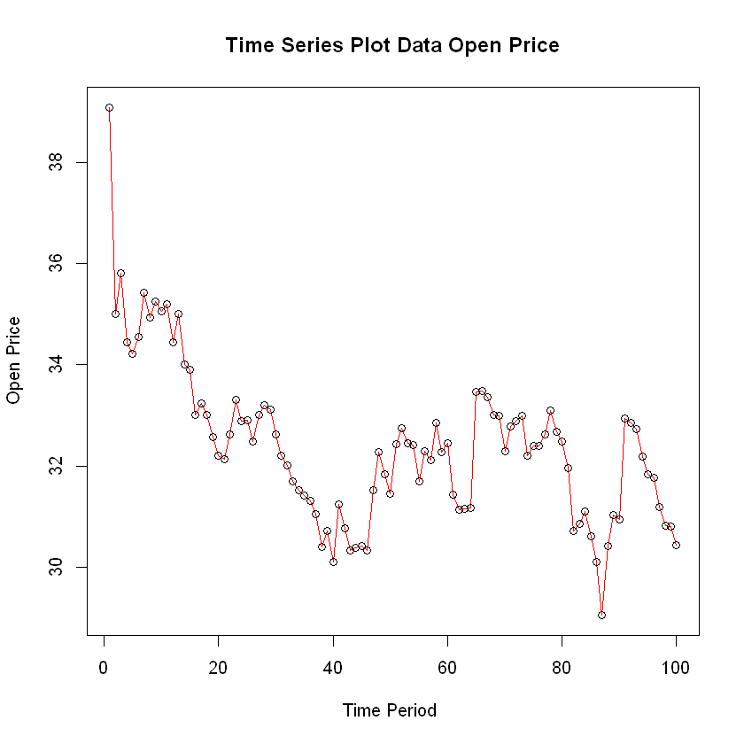

```r
ts.plot(data.ts, xlab="Time Period ", ylab="Open Price", main= "Time Series Plot Data Open Price", col="red")
points(data.ts)
```

```r
data.sma = SMA(data.ts, n=4)
data.sma
```

1. <NA>

2. <NA>

3. <NA>

4. 36.09

5. 34.8725

6. 34.7575

7. 34.66

8. 34.785

9. 35.045

10. 35.1725

11. 35.115

12. 34.9925

13. 34.93

14. 34.665

15. 34.34

16. 33.98

17. 33.5375

18. 33.29

19. 32.96

20. 32.76

21. 32.485

22. 32.3875

23. 32.5675

24. 32.735

25. 32.925

26. 32.8925

27. 32.82

28. 32.9

29. 32.9525

30. 32.9875

31. 32.7875

32. 32.49

33. 32.1375

34. 31.8625

35. 31.665

36. 31.49

37. 31.3275

38. 31.045

39. 30.87

40. 30.5675

41. 30.6175

42. 30.71

43. 30.615

44. 30.685

45. 30.4775

46. 30.3675

47. 30.6625

48. 31.1375

49. 31.4925

50. 31.7725

51. 32.0025

52. 32.12

53. 32.2725

54. 32.5125

55. 32.325

56. 32.2125

57. 32.13

58. 32.24

59. 32.3875

60. 32.425

61. 32.255

62. 31.8275

63. 31.5475

64. 31.2275

65. 31.735

66. 32.32

67. 32.87

68. 33.33

69. 33.21

70. 32.915

71. 32.7725

72. 32.74

73. 32.74

74. 32.715

75. 32.6175

76. 32.4975

77. 32.4075

78. 32.63

79. 32.7

80. 32.72

81. 32.5525

82. 31.9575

83. 31.5

84. 31.155

85. 30.8175

86. 30.665

87. 30.215

88. 30.045

89. 30.1525

90. 30.365

91. 31.3375

92. 31.9475

93. 32.37

94. 32.68

95. 32.4025

96. 32.13

97. 31.745

98. 31.405

99. 31.1475

100. 30.8125

**🖊️ Analisis :** menampilkan SMA(Simple moving Average) dengan rata-rata 4 jeda baris elemen secara berurutan.

```r
data.peramalan = c(NA,data.sma)
data.peramalan
```

1. <NA>

2. <NA>

3. <NA>

4. <NA>

5. 36.09

6. 34.8725

7. 34.7575

8. 34.66

9. 34.785

10. 35.045

11. 35.1725

12. 35.115

13. 34.9925

14. 34.93

15. 34.665

16. 34.34

17. 33.98

18. 33.5375

19. 33.29

20. 32.96

21. 32.76

22. 32.485

23. 32.3875

24. 32.5675

25. 32.735

26. 32.925

27. 32.8925

28. 32.82

29. 32.9

30. 32.9525

31. 32.9875

32. 32.7875

33. 32.49

34. 32.1375

35. 31.8625

36. 31.665

37. 31.49

38. 31.3275

39. 31.045

40. 30.87

41. 30.5675

42. 30.6175

43. 30.71

44. 30.615

45. 30.685

46. 30.4775

47. 30.3675

48. 30.6625

49. 31.1375

50. 31.4925

51. 31.7725

52. 32.0025

53. 32.12

54. 32.2725

55. 32.5125

56. 32.325

57. 32.2125

58. 32.13

59. 32.24

60. 32.3875

61. 32.425

62. 32.255

63. 31.8275

64. 31.5475

65. 31.2275

66. 31.735

67. 32.32

68. 32.87

69. 33.33

70. 33.21

71. 32.915

72. 32.7725

73. 32.74

74. 32.74

75. 32.715

76. 32.6175

77. 32.4975

78. 32.4075

79. 32.63

80. 32.7

81. 32.72

82. 32.5525

83. 31.9575

84. 31.5

85. 31.155

86. 30.8175

87. 30.665

88. 30.215

89. 30.045

90. 30.1525

91. 30.365

92. 31.3375

93. 31.9475

94. 32.37

95. 32.68

96. 32.4025

97. 32.13

98. 31.745

99. 31.405

100. 31.1475

101. 30.8125

**🖊️ Analisis :** Kali ini untuk teknik time seriesnya menambahkan nilai NA untuk memperluas data deret waktu dengan nilai prediksi Simple moving average tadi.

```r
dataku <- cbind(aktual=c(data.ts,rep(NA,5)),pemulusan=c(data.sma,rep(NA,5)) ,ramalan=c(data.peramalan,rep(data.peramalan[length(data.peramalan)],4)))
dataku
```

A matrix: 105 × 3 of type dbl

| aktual | pemulusan | ramalan |
| --- | --- | --- |
| 39.09 | NA | NA |
| 35.01 | NA | NA |
| 35.82 | NA | NA |
| 34.44 | 36.0900 | NA |
| 34.22 | 34.8725 | 36.0900 |
| 34.55 | 34.7575 | 34.8725 |
| 35.43 | 34.6600 | 34.7575 |
| 34.94 | 34.7850 | 34.6600 |
| 35.26 | 35.0450 | 34.7850 |
| 35.06 | 35.1725 | 35.0450 |
| 35.20 | 35.1150 | 35.1725 |
| 34.45 | 34.9925 | 35.1150 |
| 35.01 | 34.9300 | 34.9925 |
| 34.00 | 34.6650 | 34.9300 |
| 33.90 | 34.3400 | 34.6650 |
| 33.01 | 33.9800 | 34.3400 |
| 33.24 | 33.5375 | 33.9800 |
| 33.01 | 33.2900 | 33.5375 |
| 32.58 | 32.9600 | 33.2900 |
| 32.21 | 32.7600 | 32.9600 |
| 32.14 | 32.4850 | 32.7600 |
| 32.62 | 32.3875 | 32.4850 |
| 33.30 | 32.5675 | 32.3875 |
| 32.88 | 32.7350 | 32.5675 |
| 32.90 | 32.9250 | 32.7350 |
| 32.49 | 32.8925 | 32.9250 |
| 33.01 | 32.8200 | 32.8925 |
| 33.20 | 32.9000 | 32.8200 |
| 33.11 | 32.9525 | 32.9000 |
| 32.63 | 32.9875 | 32.9525 |
| ⋮ | ⋮ | ⋮ |
| 32.40 | 32.4975 | 32.6175 |
| 32.63 | 32.4075 | 32.4975 |
| 33.09 | 32.6300 | 32.4075 |
| 32.68 | 32.7000 | 32.6300 |
| 32.48 | 32.7200 | 32.7000 |
| 31.96 | 32.5525 | 32.7200 |
| 30.71 | 31.9575 | 32.5525 |
| 30.85 | 31.5000 | 31.9575 |
| 31.10 | 31.1550 | 31.5000 |
| 30.61 | 30.8175 | 31.1550 |
| 30.10 | 30.6650 | 30.8175 |
| 29.05 | 30.2150 | 30.6650 |
| 30.42 | 30.0450 | 30.2150 |
| 31.04 | 30.1525 | 30.0450 |
| 30.95 | 30.3650 | 30.1525 |
| 32.94 | 31.3375 | 30.3650 |
| 32.86 | 31.9475 | 31.3375 |
| 32.73 | 32.3700 | 31.9475 |
| 32.19 | 32.6800 | 32.3700 |
| 31.83 | 32.4025 | 32.6800 |
| 31.77 | 32.1300 | 32.4025 |
| 31.19 | 31.7450 | 32.1300 |
| 30.83 | 31.4050 | 31.7450 |
| 30.80 | 31.1475 | 31.4050 |
| 30.43 | 30.8125 | 31.1475 |
| NA | NA | 30.8125 |
| NA | NA | 30.8125 |
| NA | NA | 30.8125 |
| NA | NA | 30.8125 |
| NA | NA | 30.8125 |

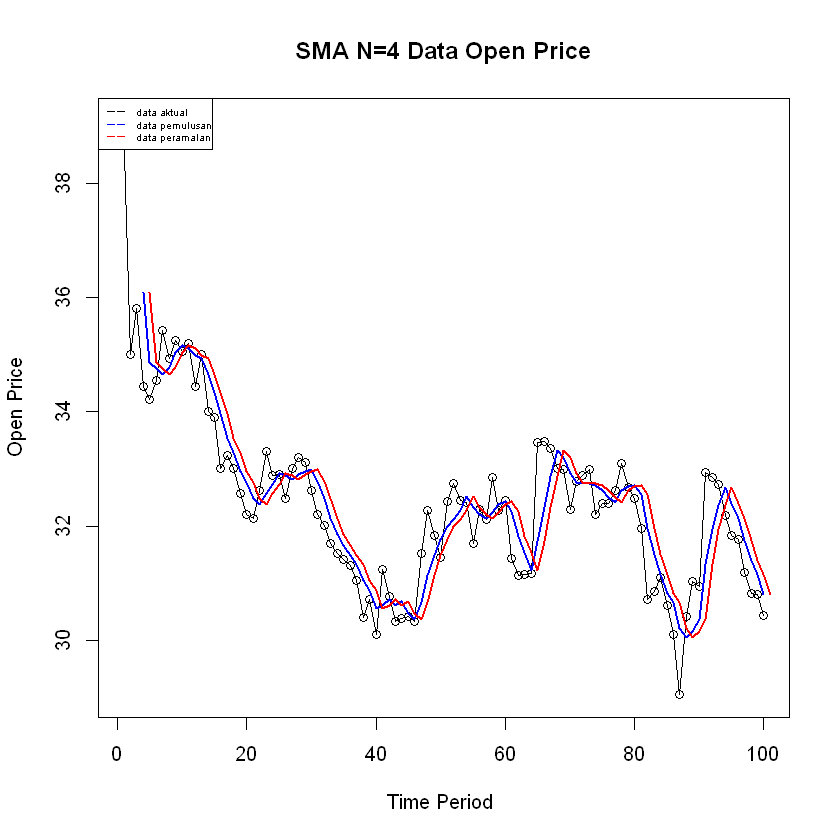

```r
ts.plot(data.ts, xlab="Time Period ", ylab="Open Price", main= "SMA N=4 Data Open Price")
points(data.ts)
lines(data.sma,col="blue",lwd=2)
lines(data.peramalan,col="red",lwd=2)
legend("topleft",c("data aktual","data pemulusan","data peramalan"), lty=5, col=c("black","blue","red"), cex=0.5)
```

**🖊️ Analisis :** Dataset di atas merupakan hasil analisa dari peramalan deret waktu. Hasil plot di atas merupaakan hasil visualisasi dari 3 data yaitu data aktual, data smoothing dan data forecasting yang ketiganya memiliki pergerakan yang hampir mirip

```r
error=data.ts-data.peramalan[1:length(data.ts)]
SSE=sum(error[5:length(data.ts)]^2)
SSE
```

61.3459624999998

```r
MSE=mean(error[5:length(data.ts)]^2)
MSE
```

0.639020442708332

```r
MAPE=mean(abs((error[5:length(data.ts)]/data.ts[5:length(data.ts)])*100))
MAPE
```

1.94089892445136

## Percobaan ke-2: Studi Kasus 2

```r
AirPassengers
```

A Time Series: 12 × 12

|  | Jan | Feb | Mar | Apr | May | Jun | Jul | Aug | Sep | Oct | Nov | Dec |
| --- | --- | --- | --- | --- | --- | --- | --- | --- | --- | --- | --- | --- |
| 1949 | 112 | 118 | 132 | 129 | 121 | 135 | 148 | 148 | 136 | 119 | 104 | 118 |
| 1950 | 115 | 126 | 141 | 135 | 125 | 149 | 170 | 170 | 158 | 133 | 114 | 140 |
| 1951 | 145 | 150 | 178 | 163 | 172 | 178 | 199 | 199 | 184 | 162 | 146 | 166 |
| 1952 | 171 | 180 | 193 | 181 | 183 | 218 | 230 | 242 | 209 | 191 | 172 | 194 |
| 1953 | 196 | 196 | 236 | 235 | 229 | 243 | 264 | 272 | 237 | 211 | 180 | 201 |
| 1954 | 204 | 188 | 235 | 227 | 234 | 264 | 302 | 293 | 259 | 229 | 203 | 229 |
| 1955 | 242 | 233 | 267 | 269 | 270 | 315 | 364 | 347 | 312 | 274 | 237 | 278 |
| 1956 | 284 | 277 | 317 | 313 | 318 | 374 | 413 | 405 | 355 | 306 | 271 | 306 |
| 1957 | 315 | 301 | 356 | 348 | 355 | 422 | 465 | 467 | 404 | 347 | 305 | 336 |
| 1958 | 340 | 318 | 362 | 348 | 363 | 435 | 491 | 505 | 404 | 359 | 310 | 337 |
| 1959 | 360 | 342 | 406 | 396 | 420 | 472 | 548 | 559 | 463 | 407 | 362 | 405 |
| 1960 | 417 | 391 | 419 | 461 | 472 | 535 | 622 | 606 | 508 | 461 | 390 | 432 |

```r
t=1:length(AirPassengers)
y=AirPassengers
trend_analysis = lm(y~t)
summary(trend_analysis)
```

```
Call:
lm(formula = y ~ t)

Residuals:
    Min      1Q  Median      3Q     Max
-93.858 -30.727  -5.757  24.489 164.999

Coefficients:
            Estimate Std. Error t value Pr(>|t|)
(Intercept) 87.65278    7.71635   11.36   <2e-16 ***
t            2.65718    0.09233   28.78   <2e-16 ***
---
Signif. codes:  0 '***' 0.001 '**' 0.01 '*' 0.05 '.' 0.1 ' ' 1

Residual standard error: 46.06 on 142 degrees of freedom
Multiple R-squared:  0.8536,	Adjusted R-squared:  0.8526
F-statistic: 828.2 on 1 and 142 DF,  p-value: < 2.2e-16
```

```
function (x, y, ...)
UseMethod("plot")
```

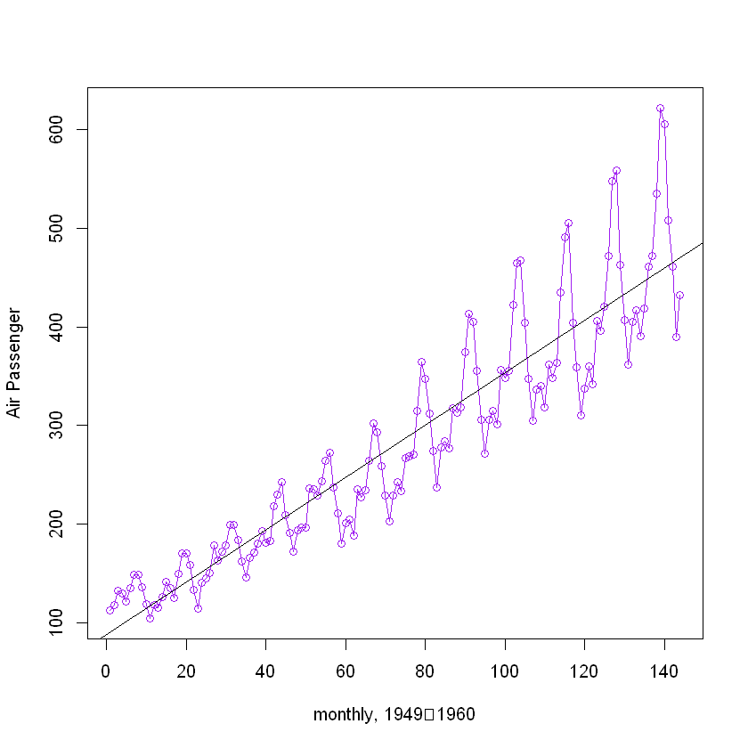

```r
plot(t,y,type="o", xlab="monthly, 1949‐1960", ylab="Air Passenger",col="purple")
plot
abline(trend_analysis)
```

## Percobaan ke-3: Studi Kasus 3

```r
data_co2 = co2
data_co2
```

A Time Series: 39 × 12

|  | Jan | Feb | Mar | Apr | May | Jun | Jul | Aug | Sep | Oct | Nov | Dec |
| --- | --- | --- | --- | --- | --- | --- | --- | --- | --- | --- | --- | --- |
| 1959 | 315.42 | 316.31 | 316.50 | 317.56 | 318.13 | 318.00 | 316.39 | 314.65 | 313.68 | 313.18 | 314.66 | 315.43 |
| 1960 | 316.27 | 316.81 | 317.42 | 318.87 | 319.87 | 319.43 | 318.01 | 315.74 | 314.00 | 313.68 | 314.84 | 316.03 |
| 1961 | 316.73 | 317.54 | 318.38 | 319.31 | 320.42 | 319.61 | 318.42 | 316.63 | 314.83 | 315.16 | 315.94 | 316.85 |
| 1962 | 317.78 | 318.40 | 319.53 | 320.42 | 320.85 | 320.45 | 319.45 | 317.25 | 316.11 | 315.27 | 316.53 | 317.53 |
| 1963 | 318.58 | 318.92 | 319.70 | 321.22 | 322.08 | 321.31 | 319.58 | 317.61 | 316.05 | 315.83 | 316.91 | 318.20 |
| 1964 | 319.41 | 320.07 | 320.74 | 321.40 | 322.06 | 321.73 | 320.27 | 318.54 | 316.54 | 316.71 | 317.53 | 318.55 |
| 1965 | 319.27 | 320.28 | 320.73 | 321.97 | 322.00 | 321.71 | 321.05 | 318.71 | 317.66 | 317.14 | 318.70 | 319.25 |
| 1966 | 320.46 | 321.43 | 322.23 | 323.54 | 323.91 | 323.59 | 322.24 | 320.20 | 318.48 | 317.94 | 319.63 | 320.87 |
| 1967 | 322.17 | 322.34 | 322.88 | 324.25 | 324.83 | 323.93 | 322.38 | 320.76 | 319.10 | 319.24 | 320.56 | 321.80 |
| 1968 | 322.40 | 322.99 | 323.73 | 324.86 | 325.40 | 325.20 | 323.98 | 321.95 | 320.18 | 320.09 | 321.16 | 322.74 |
| 1969 | 323.83 | 324.26 | 325.47 | 326.50 | 327.21 | 326.54 | 325.72 | 323.50 | 322.22 | 321.62 | 322.69 | 323.95 |
| 1970 | 324.89 | 325.82 | 326.77 | 327.97 | 327.91 | 327.50 | 326.18 | 324.53 | 322.93 | 322.90 | 323.85 | 324.96 |
| 1971 | 326.01 | 326.51 | 327.01 | 327.62 | 328.76 | 328.40 | 327.20 | 325.27 | 323.20 | 323.40 | 324.63 | 325.85 |
| 1972 | 326.60 | 327.47 | 327.58 | 329.56 | 329.90 | 328.92 | 327.88 | 326.16 | 324.68 | 325.04 | 326.34 | 327.39 |
| 1973 | 328.37 | 329.40 | 330.14 | 331.33 | 332.31 | 331.90 | 330.70 | 329.15 | 327.35 | 327.02 | 327.99 | 328.48 |
| 1974 | 329.18 | 330.55 | 331.32 | 332.48 | 332.92 | 332.08 | 331.01 | 329.23 | 327.27 | 327.21 | 328.29 | 329.41 |
| 1975 | 330.23 | 331.25 | 331.87 | 333.14 | 333.80 | 333.43 | 331.73 | 329.90 | 328.40 | 328.17 | 329.32 | 330.59 |
| 1976 | 331.58 | 332.39 | 333.33 | 334.41 | 334.71 | 334.17 | 332.89 | 330.77 | 329.14 | 328.78 | 330.14 | 331.52 |
| 1977 | 332.75 | 333.24 | 334.53 | 335.90 | 336.57 | 336.10 | 334.76 | 332.59 | 331.42 | 330.98 | 332.24 | 333.68 |
| 1978 | 334.80 | 335.22 | 336.47 | 337.59 | 337.84 | 337.72 | 336.37 | 334.51 | 332.60 | 332.38 | 333.75 | 334.78 |
| 1979 | 336.05 | 336.59 | 337.79 | 338.71 | 339.30 | 339.12 | 337.56 | 335.92 | 333.75 | 333.70 | 335.12 | 336.56 |
| 1980 | 337.84 | 338.19 | 339.91 | 340.60 | 341.29 | 341.00 | 339.39 | 337.43 | 335.72 | 335.84 | 336.93 | 338.04 |
| 1981 | 339.06 | 340.30 | 341.21 | 342.33 | 342.74 | 342.08 | 340.32 | 338.26 | 336.52 | 336.68 | 338.19 | 339.44 |
| 1982 | 340.57 | 341.44 | 342.53 | 343.39 | 343.96 | 343.18 | 341.88 | 339.65 | 337.81 | 337.69 | 339.09 | 340.32 |
| 1983 | 341.20 | 342.35 | 342.93 | 344.77 | 345.58 | 345.14 | 343.81 | 342.21 | 339.69 | 339.82 | 340.98 | 342.82 |
| 1984 | 343.52 | 344.33 | 345.11 | 346.88 | 347.25 | 346.62 | 345.22 | 343.11 | 340.90 | 341.18 | 342.80 | 344.04 |
| 1985 | 344.79 | 345.82 | 347.25 | 348.17 | 348.74 | 348.07 | 346.38 | 344.51 | 342.92 | 342.62 | 344.06 | 345.38 |
| 1986 | 346.11 | 346.78 | 347.68 | 349.37 | 350.03 | 349.37 | 347.76 | 345.73 | 344.68 | 343.99 | 345.48 | 346.72 |
| 1987 | 347.84 | 348.29 | 349.23 | 350.80 | 351.66 | 351.07 | 349.33 | 347.92 | 346.27 | 346.18 | 347.64 | 348.78 |
| 1988 | 350.25 | 351.54 | 352.05 | 353.41 | 354.04 | 353.62 | 352.22 | 350.27 | 348.55 | 348.72 | 349.91 | 351.18 |
| 1989 | 352.60 | 352.92 | 353.53 | 355.26 | 355.52 | 354.97 | 353.75 | 351.52 | 349.64 | 349.83 | 351.14 | 352.37 |
| 1990 | 353.50 | 354.55 | 355.23 | 356.04 | 357.00 | 356.07 | 354.67 | 352.76 | 350.82 | 351.04 | 352.69 | 354.07 |
| 1991 | 354.59 | 355.63 | 357.03 | 358.48 | 359.22 | 358.12 | 356.06 | 353.92 | 352.05 | 352.11 | 353.64 | 354.89 |
| 1992 | 355.88 | 356.63 | 357.72 | 359.07 | 359.58 | 359.17 | 356.94 | 354.92 | 352.94 | 353.23 | 354.09 | 355.33 |
| 1993 | 356.63 | 357.10 | 358.32 | 359.41 | 360.23 | 359.55 | 357.53 | 355.48 | 353.67 | 353.95 | 355.30 | 356.78 |
| 1994 | 358.34 | 358.89 | 359.95 | 361.25 | 361.67 | 360.94 | 359.55 | 357.49 | 355.84 | 356.00 | 357.59 | 359.05 |
| 1995 | 359.98 | 361.03 | 361.66 | 363.48 | 363.82 | 363.30 | 361.94 | 359.50 | 358.11 | 357.80 | 359.61 | 360.74 |
| 1996 | 362.09 | 363.29 | 364.06 | 364.76 | 365.45 | 365.01 | 363.70 | 361.54 | 359.51 | 359.65 | 360.80 | 362.38 |
| 1997 | 363.23 | 364.06 | 364.61 | 366.40 | 366.84 | 365.68 | 364.52 | 362.57 | 360.24 | 360.83 | 362.49 | 364.34 |

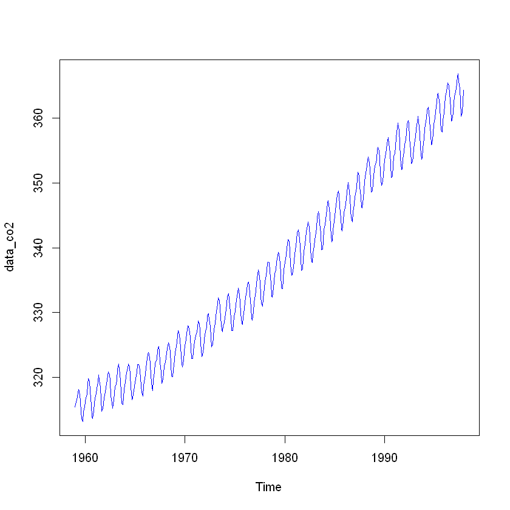

```r
plot(data_co2, col = "blue")
```

```r
model <- HoltWinters(data_co2)
model
```

```
Holt-Winters exponential smoothing with trend and additive seasonal component.

Call:
HoltWinters(x = data_co2)

Smoothing parameters:
 alpha: 0.5126484
 beta : 0.009497669
 gamma: 0.4728868

Coefficients:
           [,1]
a   364.7616237
b     0.1247438
s1    0.2215275
s2    0.9552801
s3    1.5984744
s4    2.8758029
s5    3.2820088
s6    2.4406990
s7    0.8969433
s8   -1.3796428
s9   -3.4112376
s10  -3.2570163
s11  -1.9134850
s12  -0.5844250
```

```r
fore <- predict(model, 50, prediction.interval = TRUE)
fore
```

A Time Series: 50 × 3

|  | fit | upr | lwr |
| --- | --- | --- | --- |
| Jan 1998 | 365.1079 | 365.7105 | 364.5053 |
| Feb 1998 | 365.9664 | 366.6449 | 365.2879 |
| Mar 1998 | 366.7343 | 367.4823 | 365.9864 |
| Apr 1998 | 368.1364 | 368.9490 | 367.3238 |
| May 1998 | 368.6674 | 369.5410 | 367.7937 |
| Jun 1998 | 367.9508 | 368.8824 | 367.0192 |
| Jul 1998 | 366.5318 | 367.5189 | 365.5446 |
| Aug 1998 | 364.3799 | 365.4206 | 363.3392 |
| Sep 1998 | 362.4731 | 363.5656 | 361.3806 |
| Oct 1998 | 362.7520 | 363.8948 | 361.6093 |
| Nov 1998 | 364.2203 | 365.4121 | 363.0285 |
| Dec 1998 | 365.6741 | 366.9138 | 364.4345 |
| Jan 1999 | 366.6048 | 367.9353 | 365.2744 |
| Feb 1999 | 367.4633 | 368.8383 | 366.0884 |
| Mar 1999 | 368.2313 | 369.6500 | 366.8125 |
| Apr 1999 | 369.6333 | 371.0954 | 368.1713 |
| May 1999 | 370.1643 | 371.6690 | 368.6596 |
| Jun 1999 | 369.4477 | 370.9946 | 367.9008 |
| Jul 1999 | 368.0287 | 369.6173 | 366.4401 |
| Aug 1999 | 365.8769 | 367.5068 | 364.2469 |
| Sep 1999 | 363.9700 | 365.6409 | 362.2991 |
| Oct 1999 | 364.2490 | 365.9604 | 362.5375 |
| Nov 1999 | 365.7172 | 367.4690 | 363.9655 |
| Dec 1999 | 367.1710 | 368.9628 | 365.3793 |
| Jan 2000 | 368.1017 | 369.9669 | 366.2366 |
| Feb 2000 | 368.9602 | 370.8642 | 367.0563 |
| Mar 2000 | 369.7282 | 371.6707 | 367.7857 |
| Apr 2000 | 371.1303 | 373.1111 | 369.1494 |
| May 2000 | 371.6612 | 373.6803 | 369.6421 |
| Jun 2000 | 370.9446 | 373.0018 | 368.8874 |
| Jul 2000 | 369.5256 | 371.6208 | 367.4305 |
| Aug 2000 | 367.3738 | 369.5067 | 365.2408 |
| Sep 2000 | 365.4669 | 367.6376 | 363.2963 |
| Oct 2000 | 365.7459 | 367.9541 | 363.5376 |
| Nov 2000 | 367.2142 | 369.4599 | 364.9684 |
| Dec 2000 | 368.6680 | 370.9511 | 366.3848 |
| Jan 2001 | 369.5987 | 371.9479 | 367.2494 |
| Feb 2001 | 370.4572 | 372.8432 | 368.0711 |
| Mar 2001 | 371.2251 | 373.6479 | 368.8023 |
| Apr 2001 | 372.6272 | 375.0867 | 370.1677 |
| May 2001 | 373.1581 | 375.6543 | 370.6619 |
| Jun 2001 | 372.4416 | 374.9744 | 369.9087 |
| Jul 2001 | 371.0226 | 373.5920 | 368.4531 |
| Aug 2001 | 368.8707 | 371.4767 | 366.2647 |
| Sep 2001 | 366.9639 | 369.6064 | 364.3213 |
| Oct 2001 | 367.2428 | 369.9219 | 364.5637 |
| Nov 2001 | 368.7111 | 371.4267 | 365.9955 |
| Dec 2001 | 370.1649 | 372.9170 | 367.4128 |
| Jan 2002 | 371.0956 | 373.9100 | 368.2812 |
| Feb 2002 | 371.9541 | 374.8046 | 369.1036 |

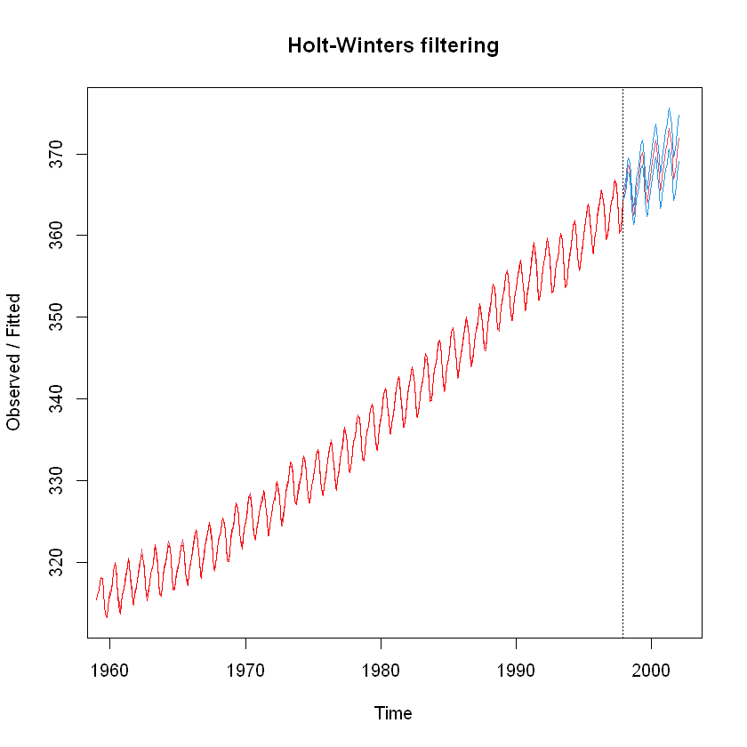

```r
plot(model,fore,col="red")
```

**🖊️ Analisis :** Dataset merupakan pengukuran konsentrasi karbondioksida (CO2) di Mauna Loa, Hawai pada tahun 1959 hingga 1997. Hasil insight didapat pola trend dan seasonal dan terdapat kenaikan setiap tahunnya. Kemudian melakukan predict untuk model dengan interval 50 prediksi ke depan dengan menggunakan motode HoltWintres.

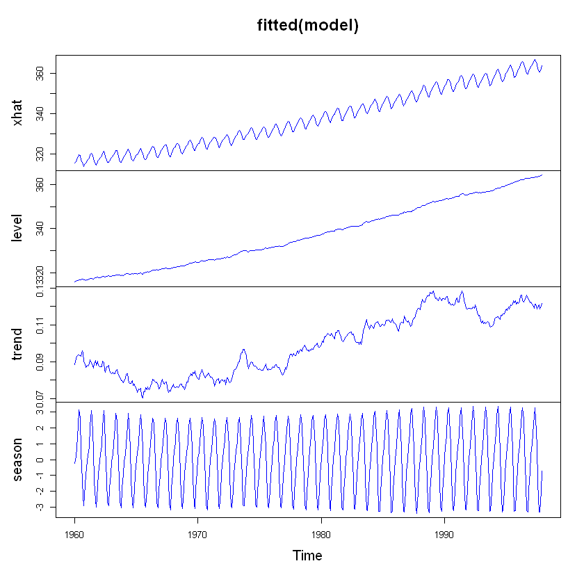

```r
plot(fitted(model),col="blue")
```

**🖊️ Analisis :** Model kemudian di fit kan. Dan dari hasil fitting model berhasil menangkap dan memvisualisasikan komponen-komponen penting dari data time series, yaitu level, trend, dan seasonality.

## Percobaan ke-4: Studi Kasus 4

```r
AirPassengers
```

A Time Series: 12 × 12

|  | Jan | Feb | Mar | Apr | May | Jun | Jul | Aug | Sep | Oct | Nov | Dec |
| --- | --- | --- | --- | --- | --- | --- | --- | --- | --- | --- | --- | --- |
| 1949 | 112 | 118 | 132 | 129 | 121 | 135 | 148 | 148 | 136 | 119 | 104 | 118 |
| 1950 | 115 | 126 | 141 | 135 | 125 | 149 | 170 | 170 | 158 | 133 | 114 | 140 |
| 1951 | 145 | 150 | 178 | 163 | 172 | 178 | 199 | 199 | 184 | 162 | 146 | 166 |
| 1952 | 171 | 180 | 193 | 181 | 183 | 218 | 230 | 242 | 209 | 191 | 172 | 194 |
| 1953 | 196 | 196 | 236 | 235 | 229 | 243 | 264 | 272 | 237 | 211 | 180 | 201 |
| 1954 | 204 | 188 | 235 | 227 | 234 | 264 | 302 | 293 | 259 | 229 | 203 | 229 |
| 1955 | 242 | 233 | 267 | 269 | 270 | 315 | 364 | 347 | 312 | 274 | 237 | 278 |
| 1956 | 284 | 277 | 317 | 313 | 318 | 374 | 413 | 405 | 355 | 306 | 271 | 306 |
| 1957 | 315 | 301 | 356 | 348 | 355 | 422 | 465 | 467 | 404 | 347 | 305 | 336 |
| 1958 | 340 | 318 | 362 | 348 | 363 | 435 | 491 | 505 | 404 | 359 | 310 | 337 |
| 1959 | 360 | 342 | 406 | 396 | 420 | 472 | 548 | 559 | 463 | 407 | 362 | 405 |
| 1960 | 417 | 391 | 419 | 461 | 472 | 535 | 622 | 606 | 508 | 461 | 390 | 432 |

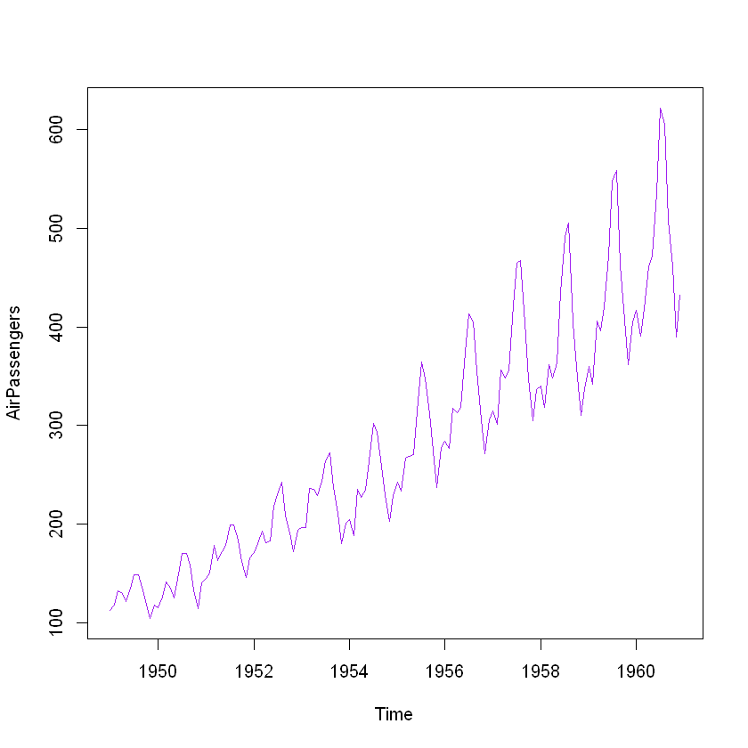

```r
plot(AirPassengers, col = "purple")
```

```r
model <- HoltWinters(AirPassengers, seasonal="mult")
model
```

```
Holt-Winters exponential smoothing with trend and multiplicative seasonal component.

Call:
HoltWinters(x = AirPassengers, seasonal = "mult")

Smoothing parameters:
 alpha: 0.2755925
 beta : 0.03269295
 gamma: 0.8707292

Coefficients:
           [,1]
a   469.3232206
b     3.0215391
s1    0.9464611
s2    0.8829239
s3    0.9717369
s4    1.0304825
s5    1.0476884
s6    1.1805272
s7    1.3590778
s8    1.3331706
s9    1.1083381
s10   0.9868813
s11   0.8361333
s12   0.9209877
```

```r
fore <- predict(model, 24, prediction.interval = TRUE)
fore
```

A Time Series: 24 × 3

|  | fit | upr | lwr |
| --- | --- | --- | --- |
| Jan 1961 | 447.0559 | 466.8057 | 427.3061 |
| Feb 1961 | 419.7123 | 440.2920 | 399.1326 |
| Mar 1961 | 464.8671 | 486.7712 | 442.9630 |
| Apr 1961 | 496.0839 | 519.3350 | 472.8329 |
| May 1961 | 507.5326 | 531.9278 | 483.1375 |
| Jun 1961 | 575.4509 | 602.1935 | 548.7083 |
| Jul 1961 | 666.5923 | 696.5558 | 636.6288 |
| Aug 1961 | 657.9137 | 688.6454 | 627.1821 |
| Sep 1961 | 550.3088 | 578.9777 | 521.6398 |
| Oct 1961 | 492.9853 | 520.9553 | 465.0153 |
| Nov 1961 | 420.2073 | 446.9458 | 393.4688 |
| Dec 1961 | 465.6345 | 487.9686 | 443.3004 |
| Jan 1962 | 481.3732 | 517.8126 | 444.9337 |
| Feb 1962 | 451.7258 | 488.0308 | 415.4207 |
| Mar 1962 | 500.1008 | 538.8928 | 461.3088 |
| Apr 1962 | 533.4477 | 574.3831 | 492.5122 |
| May 1962 | 545.5202 | 587.8399 | 503.2005 |
| Jun 1962 | 618.2550 | 664.8185 | 571.6915 |
| Jul 1962 | 715.8704 | 768.3289 | 663.4118 |
| Aug 1962 | 706.2524 | 759.2423 | 653.2626 |
| Sep 1962 | 590.4954 | 638.2882 | 542.7027 |
| Oct 1962 | 528.7681 | 574.2084 | 483.3279 |
| Nov 1962 | 450.5242 | 492.7194 | 408.3290 |
| Dec 1962 | 499.0281 | 535.8450 | 462.2112 |

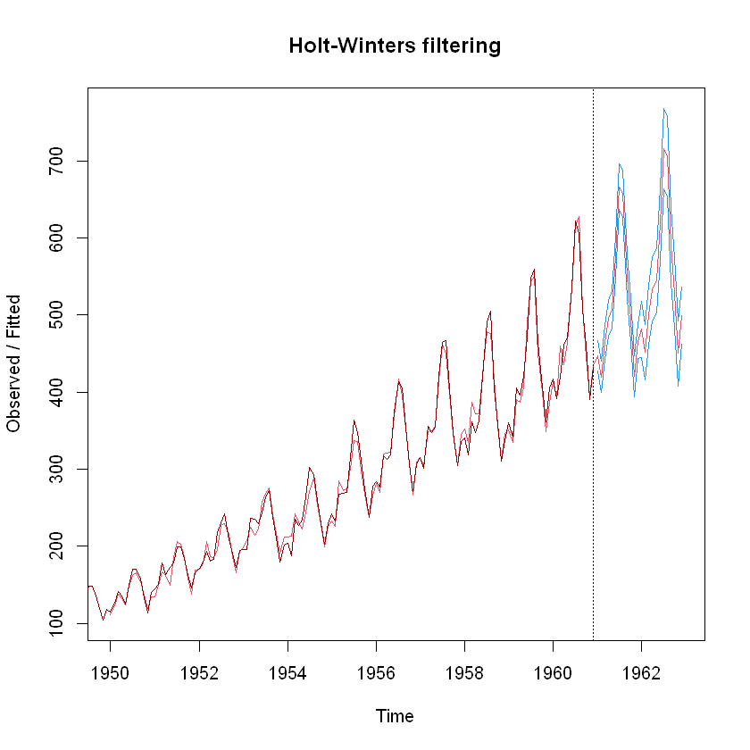

```r
plot(model,fore,col="darkred")
```

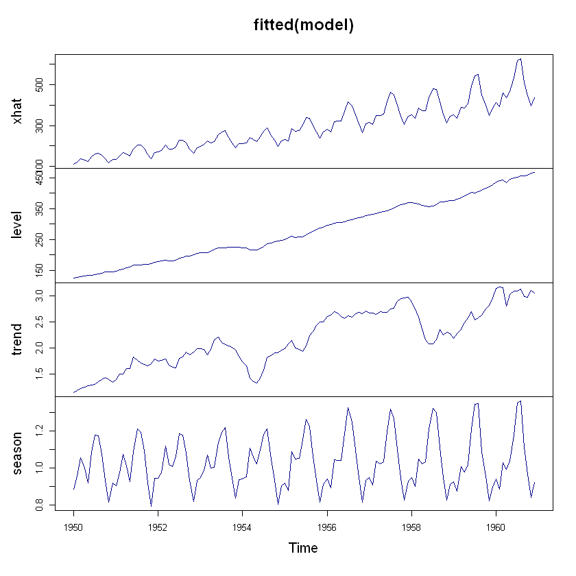

```r
plot(fitted(model),col="darkblue")
```

**🖊️ Analisis :** Sama seperti percobaan sebelumnya model menangkap dan memvisualisasikan komponen-komponen dengan sangat baik dari data time series, yaitu level, trend, dan seasonality. Model yang telah di fit menunjukkan bahwa data atau nilai pada 24 periode berikutnya cenderung naik.